# Data Analysis

- Before doing predicting analytics, we first need to explore the data

```python
# load libraries
import numpy as np
import pandas as pd

import matplotlib.pyplot as plt
import seaborn as sns
sns.set(style='darkgrid')

import matplotlib
from matplotlib import rcParams
rcParams['figure.figsize'] = 12,5
```

```python
# read data
churn = pd.read_csv('E:/ThanhTam_DA/Project/Prediction/Bank Churners/BankChurners.csv')
```

```python
churn.head()
```

|  | CLIENTNUM | Attrition_Flag | Customer_Age | Gender | Dependent_count | Education_Level | Marital_Status | Income_Category | Card_Category | Months_on_book | ... | Credit_Limit | Total_Revolving_Bal | Avg_Open_To_Buy | Total_Amt_Chng_Q4_Q1 | Total_Trans_Amt | Total_Trans_Ct | Total_Ct_Chng_Q4_Q1 | Avg_Utilization_Ratio | Naive_Bayes_Classifier_Attrition_Flag_Card_Category_Contacts_Count_12_mon_Dependent_count_Education_Level_Months_Inactive_12_mon_1 | Naive_Bayes_Classifier_Attrition_Flag_Card_Category_Contacts_Count_12_mon_Dependent_count_Education_Level_Months_Inactive_12_mon_2 |
| --- | --- | --- | --- | --- | --- | --- | --- | --- | --- | --- | --- | --- | --- | --- | --- | --- | --- | --- | --- | --- | --- |
| 0 | 768805383 | Existing Customer | 45 | M | 3 | High School | Married | $60K - $80K | Blue | 39 | ... | 12691.0 | 777 | 11914.0 | 1.335 | 1144 | 42 | 1.625 | 0.061 | 0.000093 | 0.99991 |
| 1 | 818770008 | Existing Customer | 49 | F | 5 | Graduate | Single | Less than $40K | Blue | 44 | ... | 8256.0 | 864 | 7392.0 | 1.541 | 1291 | 33 | 3.714 | 0.105 | 0.000057 | 0.99994 |
| 2 | 713982108 | Existing Customer | 51 | M | 3 | Graduate | Married | $80K - $120K | Blue | 36 | ... | 3418.0 | 0 | 3418.0 | 2.594 | 1887 | 20 | 2.333 | 0.000 | 0.000021 | 0.99998 |
| 3 | 769911858 | Existing Customer | 40 | F | 4 | High School | Unknown | Less than $40K | Blue | 34 | ... | 3313.0 | 2517 | 796.0 | 1.405 | 1171 | 20 | 2.333 | 0.760 | 0.000134 | 0.99987 |
| 4 | 709106358 | Existing Customer | 40 | M | 3 | Uneducated | Married | $60K - $80K | Blue | 21 | ... | 4716.0 | 0 | 4716.0 | 2.175 | 816 | 28 | 2.500 | 0.000 | 0.000022 | 0.99998 |

5 rows × 23 columns

```python
# drop the first index client number and two last columns which are not relevant
churn = churn.drop(["CLIENTNUM","Naive_Bayes_Classifier_Attrition_Flag_Card_Category_Contacts_Count_12_mon_Dependent_count_Education_Level_Months_Inactive_12_mon_1","Naive_Bayes_Classifier_Attrition_Flag_Card_Category_Contacts_Count_12_mon_Dependent_count_Education_Level_Months_Inactive_12_mon_2"],axis=1)
```

```python
print("No. of rows :",churn.shape[0])
print("No. of columns :",churn.shape[1])
```

```
No. of rows : 10127
No. of columns : 20
```

```python
# check missing values
churn.isna().sum().sum() # no missing values
```

```
0
```

### 1. Churned Customer Percentage

```python
churn['Attrition_Flag'].value_counts(normalize=True)
```

```
Existing Customer    0.83934
Attrited Customer    0.16066
Name: Attrition_Flag, dtype: float64
```

```python
# Replace 'Existing Customer' with 0 and 'Attrited Customer' with 1
churn['Attrition_Flag'].replace({'Existing Customer':0, 'Attrited Customer':1}, inplace=True)
churn['Attrition_Flag'].value_counts(normalize=True)
```

```
0    0.83934
1    0.16066
Name: Attrition_Flag, dtype: float64
```

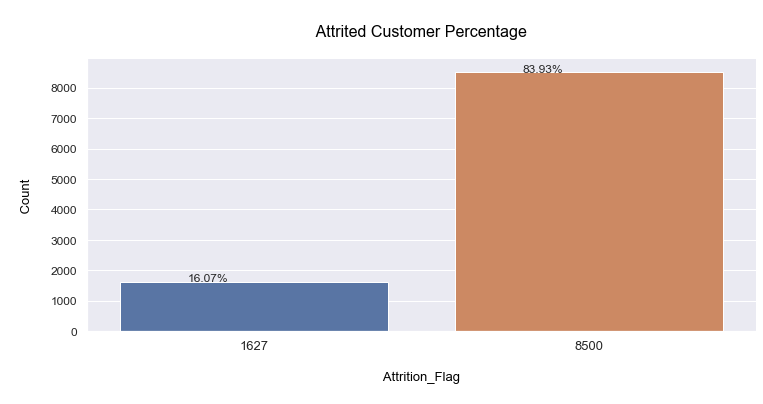

```python
lab = ["Attrited Customer","Existing Customer"]
fig, ax = plt.subplots(nrows=1, ncols=1)
a = sns.barplot(x=churn["Attrition_Flag"].value_counts(), y = churn["Attrition_Flag"].value_counts())

from IPython.core.pylabtools import figsize

#Removing top and Right borders
sns.despine(bottom = False, left = False)

spots = churn["Attrition_Flag"].value_counts()
#Putting % on the bar plot
for p in ax.patches:
    ax.text(p.get_x() + 0.2, p.get_height()+4.5, '{:.2f}%'.format((p.get_height()/10127)*100))

#Beautifying the plot
plt.title('\n Attrited Customer Percentage \n', size=16, color='black')
plt.xticks(fontsize=13)
plt.yticks(fontsize=12)
plt.xlabel('\n Attrition_Flag \n', fontsize=13, color='black')
plt.ylabel('\n Count \n', fontsize=13, color='black')
patches = [matplotlib.patches.Patch(color=sns.color_palette()[i], label=j) for i,j in zip(range(0,10),lab)]
plt.show()
```

- **Attrition_Flag** is the target variable which indicates if a customer is attrited (churned or left)
- **16%** of the customers churned which I think is high for the bank need to investigate and try to understand why these customers churned

### 2. Genearal distribution of all numerical variables

- Before go into details let's have a look of the distribution of all numerical variables

[figure not shown]

```python
# Lets change the Income Category to be useful for this analysis.

churn['Income_Category'] = churn['Income_Category'].replace(['$60K - $80K','Less than $40K',
                                                             '$80K - $120K','$40K - $60K','$120K +',
                                                             'Unknown'],[3,1,4,2,5,9999])

# Lets see the general distrubition of the numerical variables

axList = churn.hist(bins=20, figsize = (15, 15))
```

### 3. Churn Rate based on Gender and Marital Status

```python
churn[['Attrition_Flag','Gender','Marital_Status']].groupby(['Gender','Marital_Status']).mean().round(2)
```

| Gender | Marital_Status | Attrition_Flag |
| --- | --- | --- |
| F | Divorced | 0.17 |
|  | Married | 0.17 |
|  | Single | 0.18 |
|  | Unknown | 0.18 |
| M | Divorced | 0.15 |
|  | Married | 0.13 |
|  | Single | 0.16 |
|  | Unknown | 0.16 |

### 4. Average Age and Number of dependents by each group Attiriton Flag column

```python
churn[['Attrition_Flag','Customer_Age','Dependent_count']].groupby(['Attrition_Flag']).mean().round(2)
```

| Attrition_Flag | Customer_Age | Dependent_count |
| --- | --- | --- |
| 0 | 46.26 | 2.34 |
| 1 | 46.66 | 2.40 |

- The values are quite close so there seems to be **no significant difference** between churned and not-churned based on Customer Demographic age and dependents

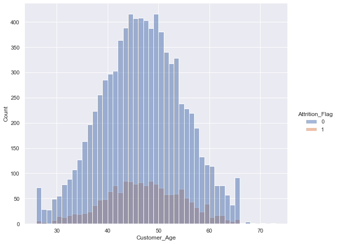

```python
sns.displot(data=churn, kind='hist',x='Customer_Age', hue='Attrition_Flag',
           height=7, aspect=1.2)
```

- Again the ditribution of customer age is similar between churned and ot churned customers. (Customer age does not seem to bean important factor in customer churn)

### 5. Credit Limit Feature and Attrition Flag

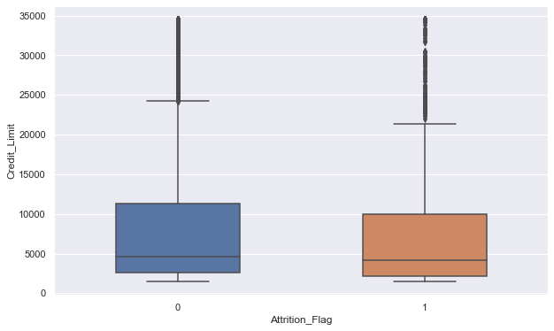

```python
plt.figure(figsize=(10,6))

sns.boxplot(data=churn, y='Credit_Limit', x='Attrition_Flag', width=0.5)
```

- The credit-limit distribution of churned and not-churned customers seem pretty similar

### 6. The number of inactive months for customers

```python
churn[['Attrition_Flag','Months_Inactive_12_mon']].groupby(['Months_Inactive_12_mon']).agg(['mean','count']).round(2)
```

| Months_Inactive_12_mon | Attrition_Flag mean | Attrition_Flag count |
| --- | --- | --- |
| 0 | 0.52 | 29 |
| 1 | 0.04 | 2233 |
| 2 | 0.15 | 3282 |
| 3 | 0.21 | 3846 |
| 4 | 0.30 | 435 |
| 5 | 0.18 | 178 |
| 6 | 0.15 | 124 |

### 7. Correlation Heatmap

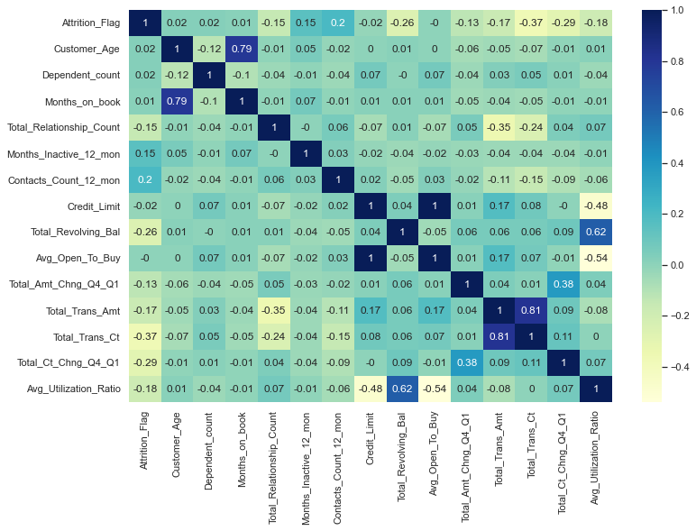

```python
corr = churn.corr().round(2)

plt.figure(figsize=(12,8))

sns.heatmap(corr, annot=True, cmap="YlGnBu")
```

- The first row/column is what we are mosly interested in. It shows the correlation coefficients between the target variable (Attrition_Flag) and the remained variables
- Total transaction count and change are higher correlated to the target variable
- We also see the high correlation (0.81) between total transaction amount and total transaction count. We can visualize these two variable for further analysis

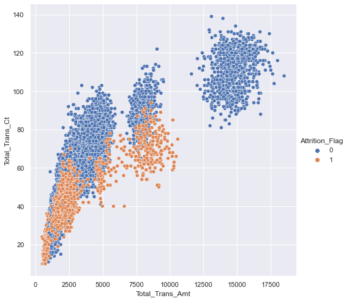

```python
sns.relplot(data=churn, kind='scatter', x='Total_Trans_Amt', y='Total_Trans_Ct',
           hue='Attrition_Flag', height=7)
```

- One interesting finding is that customer who have done more than 100 transactions do not churn !

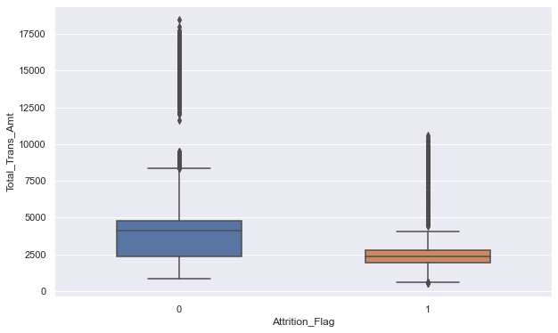

```python
# Let's create a boxplot of the total transaction amount
plt.figure(figsize=(10,6))

sns.boxplot(data=churn, y='Total_Trans_Amt', x='Attrition_Flag', width=0.5)
```

- We clearly see that the total transaction amount is higher for not-churned customers

### Variable Selection for Modelling

```python
churn.head()
```

|  | Attrition_Flag | Customer_Age | Gender | Dependent_count | Education_Level | Marital_Status | Income_Category | Card_Category | Months_on_book | Total_Relationship_Count | Months_Inactive_12_mon | Contacts_Count_12_mon | Credit_Limit | Total_Revolving_Bal | Avg_Open_To_Buy | Total_Amt_Chng_Q4_Q1 | Total_Trans_Amt | Total_Trans_Ct | Total_Ct_Chng_Q4_Q1 | Avg_Utilization_Ratio |
| --- | --- | --- | --- | --- | --- | --- | --- | --- | --- | --- | --- | --- | --- | --- | --- | --- | --- | --- | --- | --- |
| 0 | 0 | 45 | M | 3 | High School | Married | 3 | Blue | 39 | 5 | 1 | 3 | 12691.0 | 777 | 11914.0 | 1.335 | 1144 | 42 | 1.625 | 0.061 |
| 1 | 0 | 49 | F | 5 | Graduate | Single | 1 | Blue | 44 | 6 | 1 | 2 | 8256.0 | 864 | 7392.0 | 1.541 | 1291 | 33 | 3.714 | 0.105 |
| 2 | 0 | 51 | M | 3 | Graduate | Married | 4 | Blue | 36 | 4 | 1 | 0 | 3418.0 | 0 | 3418.0 | 2.594 | 1887 | 20 | 2.333 | 0.000 |
| 3 | 0 | 40 | F | 4 | High School | Unknown | 1 | Blue | 34 | 3 | 4 | 1 | 3313.0 | 2517 | 796.0 | 1.405 | 1171 | 20 | 2.333 | 0.760 |
| 4 | 0 | 40 | M | 3 | Uneducated | Married | 3 | Blue | 21 | 5 | 1 | 0 | 4716.0 | 0 | 4716.0 | 2.175 | 816 | 28 | 2.500 | 0.000 |

```python
# Replace 'Female' with 0 and 'Male' with 1
churn['Gender'].replace({'F':0, 'M':1}, inplace=True)
churn['Gender'].value_counts(normalize=True)
```

```
0    0.529081
1    0.470919
Name: Gender, dtype: float64
```

```python
# Education level
churn['Education_Level'].replace({'Uneducated':0,'High School':12, 'College':15, 'Graduate':16, 'Post-Graduate':18, 'Doctorate':22, 'Unknown':99}, inplace=True)
churn.groupby('Education_Level')['Education_Level'].count()
```

```
Education_Level
0     1487
12    2013
15    1013
16    3128
18     516
22     451
99    1519
Name: Education_Level, dtype: int64
```

```python
# Marital Status
churn['Marital_Status'].replace({'Single':0, 'Married':1, 'Divorced':3,'Unknown':9}, inplace=True)
churn.groupby('Marital_Status')['Marital_Status'].count()
```

```
Marital_Status
0    3943
1    4687
3     748
9     749
Name: Marital_Status, dtype: int64
```

```python
# Income category
churn.groupby('Income_Category')['Income_Category'].count()
```

[output not shown]

- Our dependent variable is **Attrition_Flag** (churn or not churn)
- Our other independent varables:
  - **Customer Characteristics**: Customer_Age, Gender, Dependent_Count, Education_Level, Marital_Status, Income_Category, Card_Category.
  - **Behavioral Characteristics**: Total_Relationship_Count, Months_Inactive_12_mon, Contacts_Count_12_mon, Credit_Limit, Total_Revolving_Bal, Total_Amt_Chng_Q4_Q1, Total_Trans_Amt, Total_Ct_Chng_Q4_Q1, Avg_Utilization_Ratio having the correlation with the target variable.

```python
model = churn.drop(['Months_on_book', 'Avg_Open_To_Buy', 'Total_Trans_Ct'], axis=1)
```

```python
model.to_csv('E:/ThanhTam_DA/Project/Prediction/Bank Churners/churn.csv') # save to csv file
```

Then I will use R for modelling